# Employee Salaries for different job roles

### Alejandro Borrego Megías

### 19/10/2023

# Introducción

En este proyecto se desarrolla en Python un análisis básico de datos sobre los sueldos que ganan distintos empleados según sus cometidos y experiencia, a lo largo de distintos negocios y zonas del mundo. La URL de referencia es la siguiente:

https://www.kaggle.com/datasets/inductiveanks/employee-salaries-for-different-job-roles

En ella puede encontrarse información más detallada, así como una descripción precisa de cada columna. Seguidamente, te toca a ti hacer una breve introducción, completando el fragmento de letra en azul y desarrollándolo a tu antojo.

A partir de los datos proporcionados, he conseguido afianzar mis conocimientos sobre el lenguaje Python en el manejo de estructuras de datos como diccionarios, listas, conjuntos o dataframes de pandas. Por otro lado he ampliado mis conocimientos empleando por primera técnicas de map-reduce para un caso práctico con la librería `mrjob` y en la representación de gráficos con la librería `matplotlib`. Por otro lado, por falta de tiempo debido a la carga de trabajo del master, no he conseguido completar el ejercicio *G* como me hubiera gustado, me habría gustado probar otros modelos y técnicas y compararlos.

Aunque al final de este notebook detallaré la calificación que calculo honestamente, globalmente, siguiendo las puntuaciones que se asigna a cada apartado, diría que he obtenido una nota de 10 sobre 10. </font>

# Librerías

Pongamos todas las librerías necesarias al principio, tal como propone el estilo `pep-8`. Ej.: [PEP 8 -- Style Guide for Python Code](https://www.python.org/dev/peps/pep-0008/).

```python
# Imports del módulo estándar de Python
from collections import defaultdict
from typing import List, Dict, Tuple, Optional

# Imports de terceros
import csv
import numpy as np
import pandas as pd
from matplotlib.ticker import MaxNLocator
import matplotlib.pyplot as plt
from sklearn.model_selection import train_test_split
from sklearn.decomposition import PCA
from sklearn.preprocessing import StandardScaler
from sklearn.linear_model import SGDRegressor

import ipytest
```

## a) Algunas operaciones sencillas [3 puntos]

Nuestra tabla de datos es un archivo de texto (`ds_salaries.csv`) que puede verse así con cualquier editor:

[figure not shown]

La primera columna es la cabecera, y contiene los nombres de los campos, separados por comas. Las demás, son los valores de dichos campos, consignando los datos de cada vehículo en una línea.

Si la abrimos con *excell*, vemos cada línea en una celda, sin separar los distintos campos:

[figure not shown]

## a.1) Cambiar el formato del archivo `csv` a "punto y coma"

Podemos importar la tabla de datos desde excell (pestaña `datos`), simplemente indicando que el separador es una coma:

[figure not shown]

Pero te propongo generar un archivo como el anterior, pero que use el punto y coma como separador, en vez de la coma:

[figure not shown]

Para ello, debes diseñar una función que tome con un archivo como el de partida que usa la coma como separador, y genere otro, con el punto y coma como separador.

```python
# Esta celda debe ser completada por el estudiante.
def to_semicolon (input_file_path : str, output_file_path: str):
    """
    Replace all commas with semicolons in the
    content of a CSV file and write the modified content to another file.

    Parameters
    ----------
    input_file_path, output_file_path: str
    """
    try:
        with open(input_file_path, 'r', newline='') as csvfile_input:
            csv_content = csvfile_input.read()
            csv_to_pc_content = csv_content.replace(',', ';')
    except FileNotFoundError:
        print(f"File not found: {input_file_path}")
    except Exception as e:
        print(f"An error occurred: {e}")

    try:
        with open(output_file_path, 'w') as csvfile_output:
            csvfile_output.write(csv_to_pc_content)
    except FileNotFoundError:
        print(f"File not found: {input_file_path}")
    except Exception as e:
        print(f"An error occurred: {e}")
```

```python
# Ejecución de la función anterior:

DatosComas = "ds_salaries.csv"
DatosPunComas = "ds_salaries_pc.csv"
to_semicolon(DatosComas, DatosPunComas)
```

```python
# Comprobamos que funciona como es debido, viendo las primeras cinco filas de ambos archivos:

with open(DatosComas, "r") as f:
    for _ in range(5):
        linea = f.readline()
        print(linea)

print("....................................")

with open(DatosPunComas, "r") as f:
    for _ in range(5):
        linea = f.readline()
        print(linea)
```

```
,work_year,experience_level,employment_type,job_title,salary,salary_currency,salary_in_usd,employee_residence,remote_ratio,company_location,company_size

0,2020,MI,FT,Data Scientist,70000,EUR,79833,DE,0,DE,L

1,2020,SE,FT,Machine Learning Scientist,260000,USD,260000,JP,0,JP,S

2,2020,SE,FT,Big Data Engineer,85000,GBP,109024,GB,50,GB,M

3,2020,MI,FT,Product Data Analyst,20000,USD,20000,HN,0,HN,S

....................................
;work_year;experience_level;employment_type;job_title;salary;salary_currency;salary_in_usd;employee_residence;remote_ratio;company_location;company_size

0;2020;MI;FT;Data Scientist;70000;EUR;79833;DE;0;DE;L

1;2020;SE;FT;Machine Learning Scientist;260000;USD;260000;JP;0;JP;S

2;2020;SE;FT;Big Data Engineer;85000;GBP;109024;GB;50;GB;M

3;2020;MI;FT;Product Data Analyst;20000;USD;20000;HN;0;HN;S
```

**Nota.** En la comprobación anterior, por cada línea que se imprime con la instrucción `print`, se realizan dos saltos de línea. Eso es porque las líneas anteriores se han cargado con la marca `\n`, como puedes ver a continuación, con la última línea. En las funciones que siguen deberás tener esto en cuenta para suprimir la marca `\n` cuando sea necesario.

```python
#Observa la marca "\n" al final de la última línea leída:

linea
```

```
'3;2020;MI;FT;Product Data Analyst;20000;USD;20000;HN;0;HN;S\n'
```

## a.2) Selección de una línea, separando sus campos

Diseña ahora una función que selecciona una línea y nos da una lista con los valores de sus campos. Los ejemplares de funcionamiento te darán la información sobre cómo deseamos que funcione:

```python
# Esta celda debe ser completada por el estudiante
def select_line(input_file_path: str, line_number: int) -> List[str]:
    """
    Given a file path returns a specific line

    Parameters
    ----------
    input_file_path: str
    line_number: int

    Returns
    -------
    list(str)
        Returns the line in file input_file_path in the position line_number
    """
    try:
        with open(input_file_path, 'r', newline='') as csvfile_input:
            csv_content = csvfile_input.readlines()
            return csv_content[line_number].strip().split(";")
    except FileNotFoundError:
        print(f"File not found: {input_file_path}")
        return []
    except Exception as e:
        print(f"An error occurred: {e}")
        return []
```

```python
# Comprobación del funcionamiento:

cabecera = select_line(DatosPunComas, 0)
print(cabecera)

linea_1 = select_line(DatosPunComas, 1)
print(linea_1)
```

```
['', 'work_year', 'experience_level', 'employment_type', 'job_title', 'salary', 'salary_currency', 'salary_in_usd', 'employee_residence', 'remote_ratio', 'company_location', 'company_size']
['0', '2020', 'MI', 'FT', 'Data Scientist', '70000', 'EUR', '79833', 'DE', '0', 'DE', 'L']
```

**Nota:** Observa que se suprime la marca de fin de línea, `\n`.

## a.3) Ajustes en nuestro archivo de datos

En el archivo de datos, podemos prescindir de la primera fila, que es la cabecera, y de la primera columna, pues únicamente da un número de orden de las filas, de manera que vamos a suprimir ambas, la primera fila y la primera columna; también, la columna de la experiencia será más manejable si convertimos los código en números (así: "EN" -> 0, "MI" -> 1, "EX" -> 2, "SE" -> 3) y algo parecido haremos con el tamaño de las compañías ("S" -> 1, "EX: 0, "M" -> 2, "L" -> 3). Finalmente, para nuestros fines, preferimos manejar el salario en una moneda común, de manera que descartamos las columnas relativas al sueldo en las monedas de cada país y retenemos únicamente la que refleja el salario en dólares.

Realiza estos cambios y, con ellos, genera el archivo nuevo: `DatosSalariosNormalizados.csv`.

```python
# Esta celda debe ser completada por el estudiante

def normalize_data(input_file_path: str, output_file_path: str):
    """
    Reads a CSV file, normalizes its data, and writes the result to a new CSV file.

    This function performs the following data normalization steps:
    1. Reads the CSV file specified by input_file_path.
    2. Maps the 'experience_level' and 'company_size' values using predefined dictionaries.
    3. Removes the 'salary' and 'salary_currency' columns from the data.
    4. Writes the resulting data to a new CSV file specified by output_file_path.

    Parameters
    ----------
    input_file_path : str
        The path to the input CSV file.

    output_file_path : str
        The path to the output CSV file where the normalized data will be saved.
    """
    try:
        # Define mapping dictionaries
        experience_mapping = {"EN": 0, "MI": 1, "EX": 2, "SE": 3}
        company_size_mapping = {"S": 1, "EX": 0, "M": 2, "L": 3}

        with open(input_file_path, 'r', newline='') as infile, open(output_file_path, 'w', newline='') as outfile:
            reader = infile.readlines()
            writer = csv.writer(outfile, delimiter=';')
            first_line = True
            experience_level_index = 0
            company_size_index = 0
            salary_index = 0
            salary_currency_index = 0
            for line in reader:
                row = line.strip().split(',')
                if first_line:
                    # Get special indices
                    experience_level_index = row.index('experience_level')
                    company_size_index = row.index('company_size')
                    salary_index = row.index('salary')
                    salary_currency_index = row.index('salary_currency')
                    first_line = False
                else:
                    # Extract the experience level and company size columns
                    experience_level = row[experience_level_index]
                    company_size = row[company_size_index]

                    # Normalize experience level and company size
                    experience_level = str(experience_mapping.get(experience_level, experience_level))
                    company_size = str(company_size_mapping.get(company_size, company_size))

                    # Remove salary and salary_currency columns
                    normalized_row = []
                    for index in range(len(row)):
                        if index == experience_level_index:
                            normalized_row.append(experience_level)
                        elif index == company_size_index:
                            normalized_row.append(company_size)
                        elif index == 0 or index == salary_index or index == salary_currency_index:
                            # we skip this values
                            continue
                        else:
                            normalized_row.append(row[index])

                    # Write the normalized row to the output file
                    writer.writerow(normalized_row)
    except FileNotFoundError:
        print(f"File '{input_file_path}' not found.")
    except Exception as e:
        print(f"An error occurred: {str(e)}")
```

```python
# Comprobación de funcionamiento:

DatosSalariosNormalizados = "ds_salaries.norm.csv"
normalize_data(DatosComas, DatosSalariosNormalizados)
```

En este apartado se ha conseguido completar la totalidad de los ejercicios obteniendo los resultados esperados por el profesor siguiendo la metodología de desarrollo TDD, usando como tests la salida proporcionada en el notebook. </font>

# b) extracción de algunos datos globales directamente de los archivos [2 puntos]

## b.1) Relación de puestos y su frecuencia

Con el archivo de datos normalizado, deseamos conocer la relación de los cargos que aparecen en el archivo, así como su frecuencia.

```python
def puesto_frec(input_file_path: str) -> dict:
    """
    Reads a CSV file and calculates the frequencies of job positions.

    This function reads the specified CSV file and counts the frequencies of job positions.

    Parameters
    ----------
    input_file_path : str
        The path to the input CSV file.

    Returns
    -------
    dict
        A dictionary containing the job positions (puestos) as keys and their frequencies as values.
    """
    # Initialize a dictionary to store job frequencies
    frequencies = {}

    try:
        with open(input_file_path, 'r', newline='') as infile:
            reader = infile.readlines()
            for line in reader:
                row = line.strip().split(';')
                job_position = row[3]  # Assuming the job position is in the 4th column (index 3)

                # Count the frequency of each job position
                if job_position in frequencies:
                    frequencies[job_position] += 1
                else:
                    frequencies[job_position] = 1

        return frequencies
    except FileNotFoundError:
        print(f"File '{input_file_path}' not found.")
    except Exception as e:
        print(f"An error occurred: {str(e)}")
```

```python
# Comprobación de funcionamiento:

puesto_y_frec = puesto_frec(DatosSalariosNormalizados)
puesto_y_frec
```

```
{'Data Scientist': 143,
 'Machine Learning Scientist': 8,
 'Big Data Engineer': 8,
 'Product Data Analyst': 2,
 'Machine Learning Engineer': 41,
 'Data Analyst': 97,
 'Lead Data Scientist': 3,
 'Business Data Analyst': 5,
 'Lead Data Engineer': 6,
 'Lead Data Analyst': 3,
 'Data Engineer': 132,
 'Data Science Consultant': 7,
 'BI Data Analyst': 6,
 'Director of Data Science': 7,
 'Research Scientist': 16,
 'Machine Learning Manager': 1,
 'Data Engineering Manager': 5,
 'Machine Learning Infrastructure Engineer': 3,
 'ML Engineer': 6,
 'AI Scientist': 7,
 'Computer Vision Engineer': 6,
 'Principal Data Scientist': 7,
 'Data Science Manager': 12,
 'Head of Data': 5,
 '3D Computer Vision Researcher': 1,
 'Data Analytics Engineer': 4,
 'Applied Data Scientist': 5,
 'Marketing Data Analyst': 1,
 'Cloud Data Engineer': 2,
 'Financial Data Analyst': 2,
 'Computer Vision Software Engineer': 3,
 'Director of Data Engineering': 2,
 'Data Science Engineer': 3,
 'Principal Data Engineer': 3,
 'Machine Learning Developer': 3,
 'Applied Machine Learning Scientist': 4,
 'Data Analytics Manager': 7,
 'Head of Data Science': 4,
 'Data Specialist': 1,
 'Data Architect': 11,
 'Finance Data Analyst': 1,
 'Principal Data Analyst': 2,
 'Big Data Architect': 1,
 'Staff Data Scientist': 1,
 'Analytics Engineer': 4,
 'ETL Developer': 2,
 'Head of Machine Learning': 1,
 'NLP Engineer': 1,
 'Lead Machine Learning Engineer': 1,
 'Data Analytics Lead': 1}
```

## b.2) Ídem, usando diccionarios por defecto

```python
def puesto_frec(input_file_path: str) -> defaultdict[int]:
    """
    Reads a CSV file and calculates the frequencies of job positions.

    This function reads the specified CSV file and counts the frequencies of job positions.

    Parameters
    ----------
    input_file_path : str
        The path to the input CSV file.

    Returns
    -------
    defaultdict
        A defaultdict with job positions (puestos) as keys and their frequencies as values.
    """
    # Initialize a defaultdict to store job frequencies as integers
    frequencies = defaultdict(int)

    try:
        with open(input_file_path, 'r', newline='') as infile:
            reader = infile.readlines()
            for line in reader:
                row = line.strip().split(';')
                job_position = row[3]  # Assuming the job position is in the 4th column (index 3)

                # Count the frequency of each job position
                frequencies[job_position] += 1

        return frequencies
    except FileNotFoundError:
        print(f"File '{input_file_path}' not found.")
    except Exception as e:
        print(f"An error occurred: {str(e)}")
```

```python
# Comprobación de funcionamiento:

puesto_y_frec = puesto_frec(DatosSalariosNormalizados)
puesto_y_frec
```

```
defaultdict(int,
            {'Data Scientist': 143,
             'Machine Learning Scientist': 8,
             'Big Data Engineer': 8,
             'Product Data Analyst': 2,
             'Machine Learning Engineer': 41,
             'Data Analyst': 97,
             'Lead Data Scientist': 3,
             'Business Data Analyst': 5,
             'Lead Data Engineer': 6,
             'Lead Data Analyst': 3,
             'Data Engineer': 132,
             'Data Science Consultant': 7,
             'BI Data Analyst': 6,
             'Director of Data Science': 7,
             'Research Scientist': 16,
             'Machine Learning Manager': 1,
             'Data Engineering Manager': 5,
             'Machine Learning Infrastructure Engineer': 3,
             'ML Engineer': 6,
             'AI Scientist': 7,
             'Computer Vision Engineer': 6,
             'Principal Data Scientist': 7,
             'Data Science Manager': 12,
             'Head of Data': 5,
             '3D Computer Vision Researcher': 1,
             'Data Analytics Engineer': 4,
             'Applied Data Scientist': 5,
             'Marketing Data Analyst': 1,
             'Cloud Data Engineer': 2,
             'Financial Data Analyst': 2,
             'Computer Vision Software Engineer': 3,
             'Director of Data Engineering': 2,
             'Data Science Engineer': 3,
             'Principal Data Engineer': 3,
             'Machine Learning Developer': 3,
             'Applied Machine Learning Scientist': 4,
             'Data Analytics Manager': 7,
             'Head of Data Science': 4,
             'Data Specialist': 1,
             'Data Architect': 11,
             'Finance Data Analyst': 1,
             'Principal Data Analyst': 2,
             'Big Data Architect': 1,
             'Staff Data Scientist': 1,
             'Analytics Engineer': 4,
             'ETL Developer': 2,
             'Head of Machine Learning': 1,
             'NLP Engineer': 1,
             'Lead Machine Learning Engineer': 1,
             'Data Analytics Lead': 1})
```

## b.3) Países con empleados residentes en el extranjero

```python
# Esta celda debe ser completada por el estudiante
def paises_con_empleados_en_extranjero_anno_dado(input_file_path: str, year: int):
    """
    Reads a CSV file and extracts information about job positions, country pairs, and employments for a specific year.

    This function reads the specified CSV file, filters the data based on the given year, and collects information
    about job positions, country pairs (if the source and destination countries are different), and unique employments.

    Parameters
    ----------
    input_file_path : str
        The path to the input CSV file.

    year : int
        The year to filter the data.

    Returns
    -------
    tuple
        A tuple containing:
        - employments: A set of unique job positions for the specified year.
        - country_pairs: A dictionary with pairs of source and destination countries as keys and their frequencies as values.
    """
    # Initialize sets and dictionaries to store data
    country_pairs = {}

    try:
        with open(input_file_path, 'r', newline='') as infile:
            reader = infile.readlines()
            for line in reader:
                row = line.strip().split(';')
                if row[0] == str(year):
                    if row[5] != row[7]:  # Check if source and destination countries are different
                        pair = (row[5], row[7])
                        if pair in country_pairs:
                            country_pairs[pair] += 1
                        else:
                            country_pairs[pair] = 1

        return country_pairs
    except FileNotFoundError:
        print(f"File '{input_file_path}' not found.")
    except Exception as e:
        print(f"An error occurred: {str(e)}")
```

```python
# Comprobación de funcionamiento:

paises_con_empleados_en_extranjero_anno_dado(DatosSalariosNormalizados, 2021)
```

```
{('IN', 'US'): 3,
 ('GB', 'CA'): 1,
 ('IT', 'PL'): 1,
 ('BG', 'US'): 1,
 ('GR', 'DK'): 1,
 ('BR', 'US'): 2,
 ('DE', 'US'): 1,
 ('HU', 'US'): 1,
 ('PK', 'US'): 1,
 ('ES', 'RO'): 1,
 ('VN', 'US'): 1,
 ('SG', 'IL'): 1,
 ('RO', 'US'): 1,
 ('VN', 'GB'): 1,
 ('FR', 'ES'): 1,
 ('RO', 'GB'): 1,
 ('US', 'FR'): 1,
 ('DE', 'AT'): 1,
 ('FR', 'US'): 1,
 ('IT', 'US'): 1,
 ('HK', 'GB'): 1,
 ('IN', 'CH'): 1,
 ('US', 'CA'): 1,
 ('IN', 'AS'): 1,
 ('RS', 'DE'): 1,
 ('PR', 'US'): 1,
 ('NL', 'DE'): 1,
 ('JE', 'CN'): 1}
```

## b.4) Ídem, usando diccionarios por defecto

```python
# Esta celda debe ser completada por el estudiante
def anno_cargos_paises_comps_empls(input_file_path: str, year: int):
    """
    Reads a CSV file and extracts information about job positions, country pairs, and employments for a specific year.

    This function reads the specified CSV file, filters the data based on the given year, and collects information
    about job positions, country pairs (if the source and destination countries are different), and unique employments.

    Parameters
    ----------
    input_file_path : str
        The path to the input CSV file.

    year : int
        The year to filter the data.

    Returns
    -------
    tuple
        A tuple containing:
        - employments: A set of unique job positions for the specified year.
        - country_pairs: A defaultdict with pairs of source and destination countries as keys and their frequencies as values.
    """
    # job frequences
    country_pairs = defaultdict(int)
    try:
        with open(input_file_path, 'r', newline='') as infile:
            reader = infile.readlines()
            for line in reader:
                row = line.strip().split(';')
                if row[0] == str(year):
                    if row[5] != row[7]:
                        if(row[5], row[7]) in country_pairs:
                            country_pairs[(row[5], row[7])] = country_pairs[(row[5], row[7])] + 1
                        else:
                            country_pairs[(row[5], row[7])] = 1
        return country_pairs
    except FileNotFoundError:
        print(f"File '{input_file_path}' not found.")
    except Exception as e:
        print(f"An error occurred: {str(e)}")
```

```python
anno_cargos_paises_comps_empls(DatosSalariosNormalizados, 2021)
```

```
defaultdict(int,
            {('IN', 'US'): 3,
             ('GB', 'CA'): 1,
             ('IT', 'PL'): 1,
             ('BG', 'US'): 1,
             ('GR', 'DK'): 1,
             ('BR', 'US'): 2,
             ('DE', 'US'): 1,
             ('HU', 'US'): 1,
             ('PK', 'US'): 1,
             ('ES', 'RO'): 1,
             ('VN', 'US'): 1,
             ('SG', 'IL'): 1,
             ('RO', 'US'): 1,
             ('VN', 'GB'): 1,
             ('FR', 'ES'): 1,
             ('RO', 'GB'): 1,
             ('US', 'FR'): 1,
             ('DE', 'AT'): 1,
             ('FR', 'US'): 1,
             ('IT', 'US'): 1,
             ('HK', 'GB'): 1,
             ('IN', 'CH'): 1,
             ('US', 'CA'): 1,
             ('IN', 'AS'): 1,
             ('RS', 'DE'): 1,
             ('PR', 'US'): 1,
             ('NL', 'DE'): 1,
             ('JE', 'CN'): 1})
```

En este apartado, aunque se han tenido algunos problemas lógicos a la hora de iterar sobre las estructuras de datos manejadas, finalmente se han completado con éxito todos los enunciados propuestos. </font>

# c) Un diccionario se parece a una tabla... [1'5 puntos]

## c.1) Carga de los datos en una tabla (compacta)

Para cada tipo de puesto, nivel, año y país, deseamos tener la relación de salarios. Cargaremos esta información en un diccionario cuyas claves serán tuplas (con los puestos, el nivel, el año y el país) y cuyo valor será la relación de salarios. La idea es que podamos luego acceder a la información de la siguiente manera:

```
    ('Data Scientist', 3, 2020, 'US'):
    [68428, 120000, 412000]
```

Te pido una versión de lectura de los datos en una tabla como ésta.

```python
# Esta celda debe ser completada por el estudiante

def load_salaries_compact(input_file_path: str) -> Dict[Tuple[str, int, int, str], List[int]]:
    """
    Reads a CSV file and extracts information about job positions and corresponding salary data.

    This function reads the specified CSV file, processes the data, and organizes it in a dictionary where the key is a
    tuple containing job position, year, month, and country, and the value is a list of salaries associated with that
    key.

    Parameters
    ----------
    input_file_path : str
        The path to the input CSV file.

    Returns
    -------
    Dict[Tuple[str, int, int, str], List[int]]
        A dictionary where each key is a tuple with job position, year, month, and country, and the value is a list of
        corresponding salaries.

    Raises
    ------
    FileNotFoundError
        If the specified input file is not found.

    Returns
    -------
    Dict[Tuple[str, int, int, str], List[int]]
        A dictionary containing job positions as keys and lists of associated salaries as values.
    """
    # job frequences
    compact_dict = defaultdict(list)
    try:
        with open(input_file_path, 'r', newline='') as infile:
            reader = infile.readlines()
            for line in reader:
                row = line.strip().split(';')
                key = (row[3], int(row[1]), int(row[0]), row[7])
                if key in compact_dict:
                    compact_dict[key].append(int(row[4]))
                else:
                    compact_dict[key] = [int(row[4])]
        return compact_dict
    except FileNotFoundError:
        print(f"File '{input_file_path}' not found.")
    except Exception as e:
        print(f"An error occurred: {str(e)}")
```

```python
# Comprobación:

Salarios_tabla_compact = load_salaries_compact(DatosSalariosNormalizados)
print(Salarios_tabla_compact)
```

```
defaultdict(<class 'list'>, {('Data Scientist', 1, 2020, 'DE'): [79833], ('Machine Learning Scientist', 3, 2020, 'JP'): [260000], ('Big Data Engineer', 3, 2020, 'GB'): [109024, 114047], ('Product Data Analyst', 1, 2020, 'HN'): [20000], ('Machine Learning Engineer', 3, 2020, 'US'): [150000], ('Data A…
```

## c.2) Carga de todos los datos en una tabla de tablas...

Para cada tipo de puesto, año y país, deseamos tener la relación de salarios. En esta segunda versión, cargaremos esta información en un diccionario cuyas claves serán los puestos y cuyo valor, un nuevo diccionario con el año como clave y cuyo valor será un diccionario con el país como clave y la relación de salarios como valor. Aunque esto parece algo lioso, la idea es que podamos luego acceder a la información de la siguiente manera:

[output not shown]

```python
# Esta celda debe ser completada por el estudiante
def load_salaries(input_file_path: str):
    """
    Reads a CSV file and extracts information about job positions, country pairs, and employments for a specific year.

    This function reads the specified CSV file, filters the data based on the given year, and collects information
    about job positions, country pairs (if the source and destination countries are different), and unique employments.

    Parameters
    ----------
    input_file_path : str
        The path to the input CSV file.

    Returns
    -------
    dict
        A dictionary containing the following structure:
        {
            source_country: {
                year: {
                    destination_country: [list of employment frequencies]
                }
            }
        }

    This function reads the CSV file specified by 'input_file_path' and structures the data into a nested dictionary,
    where the keys represent the source country, year, and destination country. It collects employment frequencies as a list.

    If the file does not exist, a FileNotFoundError is raised and an error message is printed. If any other error occurs
    during the file processing, an error message is printed as well.
    """
    # job frequences
    table_of_tables = defaultdict(lambda: {})
    try:
        with open(input_file_path, 'r') as infile:
            reader = infile.readlines()
            for line in reader:
                row = line.strip().split(';')
                if not row[3] in table_of_tables:
                    table_of_tables[row[3]] = defaultdict(lambda: {})
                if not int(row[0]) in table_of_tables[row[3]]:
                     table_of_tables[row[3]][int(row[0])] = defaultdict(lambda: {})
                if not row[7] in table_of_tables[row[3]] [int(row[0])]:
                    table_of_tables[row[3]] [int(row[0])][row[7]] = [int(row[4])]
                else:
                    table_of_tables[row[3]] [int(row[0])][row[7]].append(int(row[4]))
        return table_of_tables
    except FileNotFoundError:
        print(f"File '{input_file_path}' not found.")
    except Exception as e:
        print(f"An error occurred: {str(e)}")
```

```python
# Comprobación de funcionamiento, con los estados de Florida y Texas:

Salarios = load_salaries(DatosSalariosNormalizados)
print(Salarios)
```

```
defaultdict(<function load_salaries.<locals>.<lambda> at 0x000001C1C6634CC0>, {'Data Scientist': defaultdict(<function load_salaries.<locals>.<lambda> at 0x000001C1BFA420C0>, {2020: defaultdict(<function load_salaries.<locals>.<lambda> at 0x000001C1C6634C20>, {'DE': [79833, 62726, 49268], 'HU': [357…
```

## c.3) Un print legible

En la comprobación anterior, puedes observar que yo he utilizado un diccionario por defecto dentro de otro diccionario por defecto. Pero la mezcla de información impide verla con claridad. Seguramente puedes tú mostrarla de manera más legible con unas pocas instrucciones:

```python
# Esta celda debe ser completada por el estudiante

def to_string (dictionary):
    for key_1 in dictionary:
        for key_2 in dictionary[key_1]:
            for key_3 in dictionary[key_1][key_2]:
                print(key_1 + " " + str(key_2) + " " + key_3 + " -> " + str(dictionary[key_1][key_2][key_3]))

to_string(Salarios)
```

```
Data Scientist 2020 DE -> [79833, 62726, 49268]
Data Scientist 2020 HU -> [35735]
Data Scientist 2020 FR -> [51321, 39916, 42197]
Data Scientist 2020 IN -> [40481]
Data Scientist 2020 US -> [68428, 45760, 105000, 118000, 120000, 138350, 412000, 105000]
Data Scientist 2020 GB -> [76958]
Data Scientist 2020 ES -> [38776]
Data Scientist 2020 IT -> [21669]
Data Scientist 2020 AT -> [91237]
Data Scientist 2020 LU -> [62726]
Data Scientist 2021 FR -> [53192, 49646, 36643, 77684]
Data Scientist 2021 IN -> [29751, 9466, 33808, 28399, 16904]
Data Scientist 2021 US -> [73000, 100000, 80000, 82500, 150000, 5679, 147000, 160000, 135000, 165000, 115000, 90000, 130000, 100000, 58000, 109000]
Data Scientist 2021 NG -> [50000]
Data Scientist 2021 CA -> [75774, 87738, 103691]
Data Scientist 2021 UA -> [13400]
Data Scientist 2021 IL -> [119059]
Data Scientist 2021 MX -> [2859]
Data Scientist 2021 CL -> [40038]
Data Scientist 2021 DE -> [90734, 90734, 88654, 25532]
Data Scientist 2021 AT -> [61467]
Data Scientist 2021 ES -> [37825, 46809]
Data Scientist 2021 BR -> [12901]
Data Scientist 2021 GB -> [116914, 56256]
Data Scientist 2021 VN -> [4000]
Data Scientist 2021 TR -> [20171]
Data Scientist 2022 US -> [130000, 90000, 136620, 99360, 146000, 123000, 165220, 120160, 180000, 120000, 95550, 167000, 123000, 150000, 211500, 138600, 170000, 123000, 215300, 158200, 180000, 260000, 180000, 80000, 140400, 215300, 104890, 140000, 220000, 140000, 185100, 200000, 120000, 230000, 10000…
Data Scientist 2022 GB -> [117789, 104702, 65438, 39263, 71982, 45807, 183228, 91614]
Data Scientist 2022 IN -> [31615, 18442]
Data Scientist 2022 DZ -> [100000]
Data Scientist 2022 PL -> [35590]
Data Scientist 2022 CA -> [52396, 69336]
Data Scientist 2022 MY -> [40000]
Data Scientist 2022 AU -> [86703]
Data Scientist 2022 CH -> [122346]
Machine Learning Scientist 2020 JP -> [260000]
Machine Learning Scientist 2021 US -> [225000, 120000]
Machine Learning Scientist 2021 PK -> [12000]
Machine Learning Scientist 2021 CA -> [225000]
Machine Learning Scientist 2022 US -> [160000, 112300, 153000]
```

[output cut: 174 more lines]

```
Data Specialist 2021 US -> [165000]
Data Architect 2021 US -> [150000, 170000, 180000]
Data Architect 2022 CA -> [192400, 90700]
Data Architect 2022 US -> [208775, 147800, 266400, 213120, 192564, 144854]
Finance Data Analyst 2021 GB -> [61896]
Principal Data Analyst 2021 US -> [170000]
Principal Data Analyst 2022 CA -> [75000]
Big Data Architect 2021 CA -> [99703]
Staff Data Scientist 2021 US -> [105000]
Analytics Engineer 2022 US -> [175000, 135000, 205300, 184700]
ETL Developer 2022 GR -> [54957, 54957]
Head of Machine Learning 2022 IN -> [79039]
NLP Engineer 2022 US -> [37236]
Lead Machine Learning Engineer 2022 DE -> [87932]
Data Analytics Lead 2022 US -> [405000]
```

## c.4) Sueldo medio por grupos de puesto, nivel y año

Define ahora una función `sueldo_medio_agrupando` que, partiendo de la *tabla compacta* generada, proporcione el sueldo medio de un puesto de trabajo para un nivel y año dado.

```python
# Esta celda debe ser completada por el estudiante
def sueldo_medio_agrupando(compact_table: Dict[tuple, List[int]], employment: str, level: int, year: int) -> Optional[float]:
    """
    Calculate the mean salary for a specific job title, year, and difficulty level based on provided data.

    This function iterates through a given dictionary of job data, filters entries based on the provided substring,
    year, and difficulty level, and calculates the mean salary for the matching entries.

    Parameters
    ----------
    compact_table : dict
        A dictionary containing job data in the form of key-value pairs, where the keys are tuples with the
        structure (job_title, job_difficulty, job_year, job_country), and the values are lists of corresponding salaries.

    employment : str
        A substring that is used to filter job titles. Job titles starting with this substring will be considered.

    level : int
        The difficulty level for which salaries should be considered.

    year : int
        The specific year for which salaries should be considered.

    Returns
    -------
    float or None
        The mean salary for the specified job title, year, and difficulty level, or None if no matching data is found.
    """
    matching_salaries = []

    for key in compact_table:
        job_title, job_difficulty, job_year, job_country = key
        if (
            employment in job_title and
            job_year == year and
            job_difficulty == level
        ):
            matching_salaries.extend(compact_table[key])

    if matching_salaries:
        mean_salary = sum(matching_salaries) / len(matching_salaries)
        return round(mean_salary, 1)
    else:
        return None  # Return None if no matching data is found
```

```python
# Comprobación:

for cargo in ["Data Sci", "Machine", "Data Engi"]:
    print(cargo, sueldo_medio_agrupando(Salarios_tabla_compact, cargo, 3, 2022))
```

```
Data Sci 161890.3
Machine 138693.6
Data Engi 140939.5
```

# c.5) Un cálculo con la tabla anterior

Cálculo del sueldo medio de un puesto de trabajo en un año y país dados. Para facilitar la lectura, redondeamos a dos decimales las medias. En esta función, debes tener cuidado con las situaciones posibles en que no existen salarios, pues la media se calcularçia erróneamente.

```python
# Esta celda debe ser completada por el estudiante
def average_salary_with_dict(table_of_tables: Dict[str, Dict[int, Dict[str, List[int]]]], job: str, year: int, country: str) -> Optional[float]:
    """
    Calculate the average salary for a specific job, year, and country from a nested dictionary.

    Parameters:
    - table_of_tables (Dict[str, Dict[int, Dict[str, List[int]]]): A nested dictionary containing salary information.
    - job (str): The job title.
    - year (int): The year for which you want to calculate the average salary.
    - country (str): The country for which you want to calculate the average salary.

    Returns:
    - Optional[float]: The average salary for the specified job, year, and country, rounded to two decimal places.
      Returns 0 if the list of salaries is empty or there is a missing field in the dictionary.
    """
    try:
        matching_salaries = table_of_tables[job][year][country]
    except:
        return 0

    if not matching_salaries:
        return 0

    mean_salary = sum(matching_salaries) / len(matching_salaries)
    return round(mean_salary, 2)
```

```python
# Comprobación de funcionamiento:

for anno in range(2020, 2024):
    print(anno, average_salary_with_dict(Salarios, "Data Scientist", anno, "US"))
```

```
2020 139067.25
2021 106261.19
2022 153483.33
2023 0
```

**Nota.** Observa que, si la tabla no contiene la información para un año (ej, 2023), la función da un cero, y no un error.

En este apartado se ha profundizado en el conocimiento de diccionarios en Python y se ha logrado completar con éxito cada sub apartado. </font>

## d) Algunas gráficas [1 punto]

## d.1) Un modelo típico de gráfica

Vamos a diseñar un modelo de gráfica sencillo que nos sirva para las siguientes representaciones. Tomará como parámetro una lista de pares $(x, y)$, y opcionalmente los tres rótulos explicativos que necesitamos incluir. Además, queremos que las etiquetas de las abcisas aparezcan inclinadas, para poder luego mostrar intervalos de edad.

Las pruebas de funcionamiento te darán más información que las explicaciones que pueda yo dar aquí.

```python
# Esta celda debe ser completada por el estudiante

def representar_xxx_yyy(data, title_labels=None):
    """
    Plot data points and add legends to a Matplotlib plot.

    Parameters:
    - data (list of tuples): List of (x, y) data points to be plotted.
    - legend_labels (list of str): List of legend labels corresponding to the data series.

    Example:
    representar_xxx_yyy([(1, 8), (2, 4), (3, 2), (4, 1), (5, 0.5), (6, 0.25)],
                        ["Serie descendente", "Ordenadas", "Abcisas"])
    """
    # Unzip the data points into separate lists for x and y coordinates
    x_values, y_values = zip(*data)

    # Create a Matplotlib figure and axis
    fig, ax = plt.subplots()

    # Plot the data points
    ax.plot(x_values, y_values)

    if title_labels:
        # Set title and axis labels
        ax.set_title(title_labels[0])
        ax.set_xlabel(title_labels[1])
        ax.set_ylabel(title_labels[2])

    # Add grid
    ax.grid(True)
    ax.xaxis.set_major_locator(MaxNLocator(integer=True))

    # Display the plot
    plt.show()
```

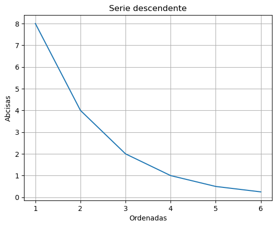

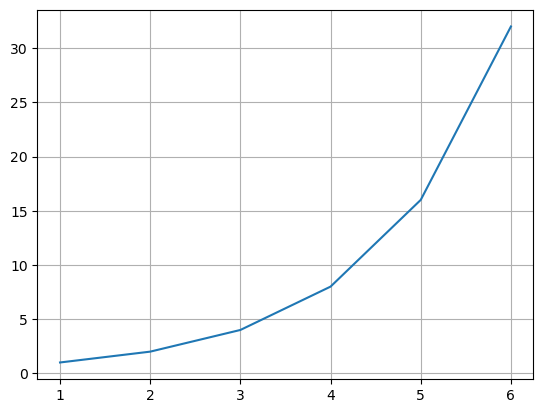

```python
# Pruebas de funcionamiento:

representar_xxx_yyy([(1, 8), (2, 4), (3, 2), (4, 1), (5, 0.5), (6, 0.25)], ["Serie descendente", "Ordenadas", "Abcisas"])

representar_xxx_yyy([(1, 1), (2, 2), (3, 4), (4, 8), (5, 16), (6, 32)])
```

Lógicamente, hemos diseñado nuestro modelo para aplicarlo posteriormente a los datos que ya tenemos. Concretamente, podemos aplicarlo también a la representación de los sueldos medios registrados en cada año.

```
[(2020, 179333.33), (2021, 147750.0), (2022, 175099.11)]
```

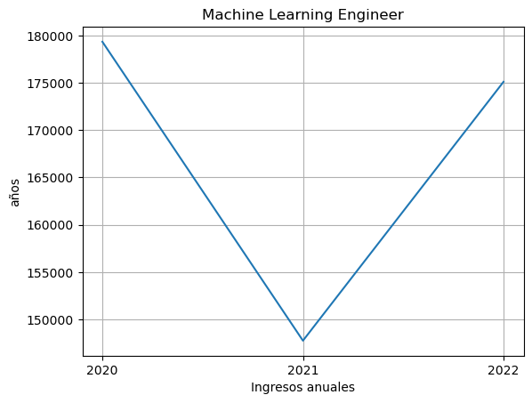

```python
# Pruebas de funcionamiento:

annos = range(2020, 2023)
annos_sueldos = [(anno, average_salary_with_dict(Salarios, "Machine Learning Engineer", anno, "US")) for anno in list(annos)]

print(annos_sueldos)

representar_xxx_yyy(annos_sueldos, ["Machine Learning Engineer", "Ingresos anuales", "años"])
```

```
[(2020, 179333.33), (2021, 147750.0), (2022, 175099.11)]
```

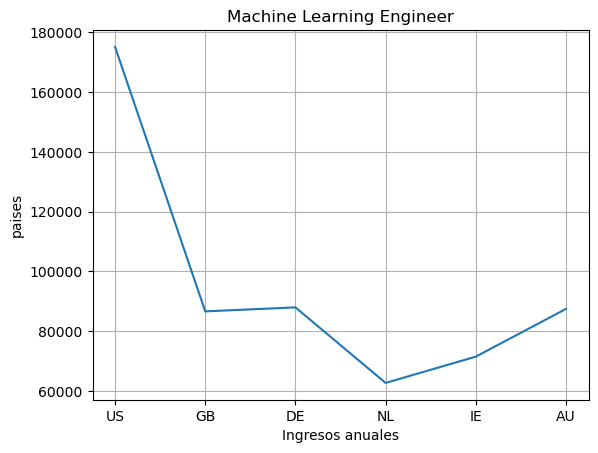

```python
# Pruebas de funcionamiento:

paises = ["US", "GB", "DE", "NL", "IE", "AU"]

paises_sueldos = [(pais, average_salary_with_dict(Salarios, "Machine Learning Engineer", 2022, pais)) for pais in paises]

print(annos_sueldos)

representar_xxx_yyy(paises_sueldos, ["Machine Learning Engineer", "Ingresos anuales", "paises"])
```

## d.2) Histograma

Un gráfico más adecuado para este cometido es el histograma.

Las pruebas de funcionamiento te darán más información que las explicaciones que pueda yo dar aquí.

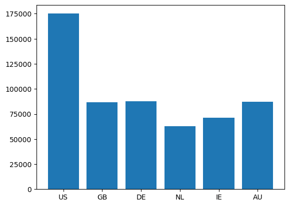

```python
# Esta celda debe ser completada por el estudiante

# Extract the string labels and integer values
labels, values = zip(*paises_sueldos)

# Create a range of numerical values for the x-axis
x = np.arange(len(labels))

# Create a bar plot using the numerical values
plt.bar(x, values)

# Set the x-tick labels as the original string labels
plt.xticks(x, labels)

# Display the plot
plt.show()
```

En este apartado se ha profundizado en el conocimiento de matplotlib y se ha logrado completar con éxito todos los ejercicios. Como único detalle pendiente, los tamaños de los gráficos parecen no ser iguales que en el notebook original, salvo eso los gráficos resultantes son idénticos. </font>

# e) Operaciones con dataframes [2 puntos]

En este apartado, vamos a trabajar con tablas de la librería `pandas`, llamadas `dataframes`.

## e.1) Carga del dataframe

La primera operación que necesitamos es cargar el archivo de datos en una tabla, como se ve en el siguiente ejemplo.

```python
# Esta celda debe ser completada por el estudiante
def load_dataframe(csv_file):
    """
    Load data from a CSV file into a Pandas DataFrame.

    Parameters:
    - csv_file (str): Path to the CSV file.

    Returns:
    - df (pd.DataFrame): The loaded DataFrame.
    """
    try:
        df = pd.read_csv(csv_file, delimiter= ';')
        return df
    except Exception as e:
        print("Error loading data:", str(e))
        return None
```

```python
# Comprobación

tabla_completa = load_dataframe(DatosPunComas)
tabla_completa
```

|  | Unnamed: 0 | work_year | experience_level | employment_type | job_title | salary | salary_currency | salary_in_usd | employee_residence | remote_ratio | company_location | company_size |
| --- | --- | --- | --- | --- | --- | --- | --- | --- | --- | --- | --- | --- |
| 0 | 0 | 2020 | MI | FT | Data Scientist | 70000 | EUR | 79833 | DE | 0 | DE | L |
| 1 | 1 | 2020 | SE | FT | Machine Learning Scientist | 260000 | USD | 260000 | JP | 0 | JP | S |
| 2 | 2 | 2020 | SE | FT | Big Data Engineer | 85000 | GBP | 109024 | GB | 50 | GB | M |
| 3 | 3 | 2020 | MI | FT | Product Data Analyst | 20000 | USD | 20000 | HN | 0 | HN | S |
| 4 | 4 | 2020 | SE | FT | Machine Learning Engineer | 150000 | USD | 150000 | US | 50 | US | L |
| ... | ... | ... | ... | ... | ... | ... | ... | ... | ... | ... | ... | ... |
| 602 | 602 | 2022 | SE | FT | Data Engineer | 154000 | USD | 154000 | US | 100 | US | M |
| 603 | 603 | 2022 | SE | FT | Data Engineer | 126000 | USD | 126000 | US | 100 | US | M |
| 604 | 604 | 2022 | SE | FT | Data Analyst | 129000 | USD | 129000 | US | 0 | US | M |
| 605 | 605 | 2022 | SE | FT | Data Analyst | 150000 | USD | 150000 | US | 100 | US | M |
| 606 | 606 | 2022 | MI | FT | AI Scientist | 200000 | USD | 200000 | IN | 100 | US | L |

607 rows × 12 columns

## e.2) Ajustes en nuestro archivo de datos

Deseamos ahora prescidir de la primera columna, pues únicamente da un número de orden de las filas, así como de las columnas relativas a la moneda local (`salary` y `salary currency`).

```python
# Esta celda debe ser completada por el estudiante
# Delete first column
tabla_abreviada = tabla_completa.drop(tabla_completa.columns[0], axis=1)
columns_to_drop = ['salary', 'salary_currency']
# Drop salary and salary_currency columns
tabla_abreviada = tabla_abreviada.drop(columns=columns_to_drop)
```

```python
# Comprobación

tabla_abreviada
```

|  | work_year | experience_level | employment_type | job_title | salary_in_usd | employee_residence | remote_ratio | company_location | company_size |
| --- | --- | --- | --- | --- | --- | --- | --- | --- | --- |
| 0 | 2020 | MI | FT | Data Scientist | 79833 | DE | 0 | DE | L |
| 1 | 2020 | SE | FT | Machine Learning Scientist | 260000 | JP | 0 | JP | S |
| 2 | 2020 | SE | FT | Big Data Engineer | 109024 | GB | 50 | GB | M |
| 3 | 2020 | MI | FT | Product Data Analyst | 20000 | HN | 0 | HN | S |
| 4 | 2020 | SE | FT | Machine Learning Engineer | 150000 | US | 50 | US | L |
| ... | ... | ... | ... | ... | ... | ... | ... | ... | ... |
| 602 | 2022 | SE | FT | Data Engineer | 154000 | US | 100 | US | M |
| 603 | 2022 | SE | FT | Data Engineer | 126000 | US | 100 | US | M |
| 604 | 2022 | SE | FT | Data Analyst | 129000 | US | 0 | US | M |
| 605 | 2022 | SE | FT | Data Analyst | 150000 | US | 100 | US | M |
| 606 | 2022 | MI | FT | AI Scientist | 200000 | IN | 100 | US | L |

607 rows × 9 columns

Comprobamos también los tipos de datos de las columnas, para asegurarnos de que los datos numéricos se han cargado como tales; de lo contrario, deberíamos cambiar su tipo.

```python
# Comprobación

tabla_abreviada.dtypes
```

```
work_year              int64
experience_level      object
employment_type       object
job_title             object
salary_in_usd          int64
employee_residence    object
remote_ratio           int64
company_location      object
company_size          object
dtype: object
```

Aunque sólo sea a efectos didácticos, la columna de los porcentajes debería ser un real... Cambia esto, sólo para practicar.

```python
# Esta celda debe ser completada por el estudiante
tabla_abreviada['remote_ratio'] = tabla_abreviada['remote_ratio'].astype(float)
```

```python
# Comprobación

tabla_abreviada.dtypes
```

```
work_year               int64
experience_level       object
employment_type        object
job_title              object
salary_in_usd           int64
employee_residence     object
remote_ratio          float64
company_location       object
company_size           object
dtype: object
```

```python
# Comprobación

tabla_abreviada
```

|  | work_year | experience_level | employment_type | job_title | salary_in_usd | employee_residence | remote_ratio | company_location | company_size |
| --- | --- | --- | --- | --- | --- | --- | --- | --- | --- |
| 0 | 2020 | MI | FT | Data Scientist | 79833 | DE | 0.0 | DE | L |
| 1 | 2020 | SE | FT | Machine Learning Scientist | 260000 | JP | 0.0 | JP | S |
| 2 | 2020 | SE | FT | Big Data Engineer | 109024 | GB | 50.0 | GB | M |
| 3 | 2020 | MI | FT | Product Data Analyst | 20000 | HN | 0.0 | HN | S |
| 4 | 2020 | SE | FT | Machine Learning Engineer | 150000 | US | 50.0 | US | L |
| ... | ... | ... | ... | ... | ... | ... | ... | ... | ... |
| 602 | 2022 | SE | FT | Data Engineer | 154000 | US | 100.0 | US | M |
| 603 | 2022 | SE | FT | Data Engineer | 126000 | US | 100.0 | US | M |
| 604 | 2022 | SE | FT | Data Analyst | 129000 | US | 0.0 | US | M |
| 605 | 2022 | SE | FT | Data Analyst | 150000 | US | 100.0 | US | M |
| 606 | 2022 | MI | FT | AI Scientist | 200000 | IN | 100.0 | US | L |

607 rows × 9 columns

```python
# Esta celda debe ser completada por el estudiante
experience_level_dict = { "EN": 0, "MI": 1, "EX": 2, "SE": 3}
company_size_dict = {"S": 1, "EX": 0, "M": 2, "L": 3}

tabla_abreviada['experience_level'] = tabla_abreviada['experience_level'].map(experience_level_dict)
tabla_abreviada['company_size'] = tabla_abreviada['company_size'].map(company_size_dict)
```

```python
# Comprobación

tabla_abreviada
```

|  | work_year | experience_level | employment_type | job_title | salary_in_usd | employee_residence | remote_ratio | company_location | company_size |
| --- | --- | --- | --- | --- | --- | --- | --- | --- | --- |
| 0 | 2020 | 1 | FT | Data Scientist | 79833 | DE | 0.0 | DE | 3 |
| 1 | 2020 | 3 | FT | Machine Learning Scientist | 260000 | JP | 0.0 | JP | 1 |
| 2 | 2020 | 3 | FT | Big Data Engineer | 109024 | GB | 50.0 | GB | 2 |
| 3 | 2020 | 1 | FT | Product Data Analyst | 20000 | HN | 0.0 | HN | 1 |
| 4 | 2020 | 3 | FT | Machine Learning Engineer | 150000 | US | 50.0 | US | 3 |
| ... | ... | ... | ... | ... | ... | ... | ... | ... | ... |
| 602 | 2022 | 3 | FT | Data Engineer | 154000 | US | 100.0 | US | 2 |
| 603 | 2022 | 3 | FT | Data Engineer | 126000 | US | 100.0 | US | 2 |
| 604 | 2022 | 3 | FT | Data Analyst | 129000 | US | 0.0 | US | 2 |
| 605 | 2022 | 3 | FT | Data Analyst | 150000 | US | 100.0 | US | 2 |
| 606 | 2022 | 1 | FT | AI Scientist | 200000 | IN | 100.0 | US | 3 |

607 rows × 9 columns

```python
# Esta celda debe ser completada por el estudiante
def average_salary_with_dataframe(df: pd.DataFrame, job: str, year: int, country: str) -> Optional[float]:
    """
    Calculate the average salary for a specific job, year, and country from a pandas DataFrame.

    Parameters:
    - df (pd.DataFrame): A DataFrame containing salary information.
    - job (str): The job title.
    - year (int): The year for which you want to calculate the average salary.
    - country (str): The country for which you want to calculate the average salary.

    Returns:
    - Optional[float]: The average salary for the specified job, year, and country, rounded to two decimal places.
      Returns 0 if the list of salaries is empty or there is no matching data in the DataFrame.
    """
    try:
        matching_salaries = df[(df['job_title'] == job) & (df['work_year'] == year) & (df['company_location'] == country)]['salary_in_usd'].values
    except (IndexError, KeyError):
        return 0

    if len(matching_salaries) == 0:
        return 0

    mean_salary = sum(matching_salaries) / len(matching_salaries)
    return round(mean_salary, 2)
```

```python
print(average_salary_with_dataframe(tabla_abreviada, "Data Scientist", 2020, "US"))
```

```
139067.25
```

Comprobamos que el resultado es el mismo que el que definimos usando el diccionario:

```python
print(average_salary_with_dict(Salarios, "Data Scientist", 2020, "US"))
```

```
139067.25
```

En este apartado se ha profundizado en el conocimiento de la librería de `pandas`. Se han completado con éxito todos los apartados. </font>

## f) Un cálculo masivo con map-reduce [Resuelto]

```
C:\...> python puestos_trabajo.py -q ds_salaries.norm.csv
```

El programa funcionará necesariamente con la técnica map-reduce, que podemos poner en juego con la librería `mrjob`.

El funcionamiento del mismo se puede activar también desde aquí:

```python
# Hagamos una llamada al programa de consola desde aquí:

! python puestos_trabajo.py -q ds_salaries.norm.csv
```

```
["3D Computer Vision Researcher","IN"]	5409
["AI Scientist","AS"]	18053
["AI Scientist","DK"]	45896
["AI Scientist","ES"]	55000
["AI Scientist","US"]	200000
["Analytics Engineer","US"]	205300
["Applied Data Scientist","CA"]	54238
["Applied Data Scientist","GB"]	110037
["Applied Data Scientist","US"]	380000
["Applied Machine Learning Scientist","CZ"]	31875
["Applied Machine Learning Scientist","US"]	423000
["BI Data Analyst","KE"]	9272
["BI Data Analyst","US"]	150000
["Big Data Architect","CA"]	99703
["Big Data Engineer","CH"]	5882
["Big Data Engineer","GB"]	114047
["Big Data Engineer","IN"]	22611
["Big Data Engineer","MD"]	18000
["Big Data Engineer","RO"]	60000
["Big Data Engineer","US"]	70000
["Business Data Analyst","CA"]	70912
["Business Data Analyst","IN"]	18442
["Business Data Analyst","LU"]	59102
["Business Data Analyst","US"]	135000
["Cloud Data Engineer","SG"]	89294
["Cloud Data Engineer","US"]	160000
["Computer Vision Engineer","BR"]	24000
["Computer Vision Engineer","DK"]	28609
["Computer Vision Engineer","LU"]	10000
["Computer Vision Engineer","US"]	125000
["Computer Vision Software Engineer","AU"]	150000
["Computer Vision Software Engineer","US"]	95746
["Data Analyst","CA"]	130000
["Data Analyst","DE"]	63831
["Data Analyst","ES"]	43966
["Data Analyst","FR"]	59102
["Data Analyst","GB"]	65438
["Data Analyst","GR"]	43966
["Data Analyst","IN"]	6072
["Data Analyst","NG"]	10000
```

[output cut: 124 more lines]

```
["Principal Data Engineer","US"]	600000
["Principal Data Scientist","DE"]	173762
["Principal Data Scientist","US"]	416000
["Product Data Analyst","HN"]	20000
["Product Data Analyst","IN"]	6072
["Research Scientist","AT"]	64849
["Research Scientist","CA"]	187442
["Research Scientist","CN"]	100000
["Research Scientist","CZ"]	69999
["Research Scientist","FR"]	93427
["Research Scientist","GB"]	82528
["Research Scientist","NL"]	42000
["Research Scientist","PT"]	60757
["Research Scientist","US"]	450000
["Staff Data Scientist","US"]	105000
```

```python
# Para que el resultado se almacene en un archivo:

! python puestos_trabajo.py -q ds_salaries.norm.csv  > sueldos_maximos.txt
```

Para que pueda yo ver tu programa cómodamente desde aquí, también se puede mostrar con un comando de la consola, anteponiendo el símbolo `!`. Observaciones:

- La instrucción siguiente está comentada para ocultar una solución mía. Tú debes suprimir el símbolo `#` del comentario para mostrar tu solución aquí.
- Desde mac o linux, se ha de usar el comando `cat`, en vez de `type`.

```python
! type puestos_trabajo.py
```

```
# -*- coding: utf-8 -*-
"""
@author: CPAREJA
"""

from mrjob.job import MRJob

class MRTotalesPuestos_Salarios(MRJob):

    def mapper(self, _, line):
        linea = line.rstrip().split(";")
        cargo, sueldo, pais = linea[3], linea[4], linea[7]
        yield (cargo, pais), int(sueldo)

    def reducer(self, key, values):
        yield key, max(values)

if __name__ == '__main__':
    MRTotalesPuestos_Salarios.run()
```

## f_bis) Un cálculo masivo con map-reduce [0.5 puntos]

Como la solución del apartado anterior se entregó por error mío, puedes, si lo deseas, inventar tú mismo un nuevo enunciado para ser resuelto con la técnica de *map-reduce*, y proponer luego una solución para el mismo.

**Enunciado propuesto**

Implementa un script de python para que, empleando la técnica map-reduce, obtengamos para un país de residencia de empleado, un año dado y un puesto de trabajo especificado, el número de empleados que hay en los distintos niveles de experiencia (es decir, cuantos empleados hay con nivel de experiencia 1, 2, etc...).

**Aclaraciones**

Se tomarán todas las líneas que contengan en el puesto de trabajo el puesto especificado por el usuario, es decir, si se introduce como puesto de trabajo *Data Scientist* serán válidos todos los puestos de trabajo que lo incluyan, como por ejemplo *Leader Data Scientist*.

```python
# El script implementado es el siguiente:
! type paises_puestos_experiencia.py
```

```
# -*- coding: utf-8 -*-
"""
@author: Alejandro Borrego Megías
"""

from mrjob.job import MRJob

class MRTotalesPuestosSalarios(MRJob):
    def configure_args(self):
        super(MRTotalesPuestosSalarios, self).configure_args()
        self.add_passthru_arg('--country', default='US', help="Indica el código del país")
        self.add_passthru_arg('--job', default='Data Scientist', help="Indica el puesto de trabajo")
        self.add_passthru_arg('--year', default=2020, help="Indica el año")

    def mapper(self, _, line):
        linea = line.rstrip().split(";")
        pais, cargo, anno, experiencia = linea[7], linea[3], linea[0], linea[1]
        if pais == self.options.country and self.options.job in cargo and anno == str(self.options.year):
            yield (pais, cargo, anno, experiencia), 1

    def reducer(self, key, values):
        yield key, sum(values)

if __name__ == '__main__':
    MRTotalesPuestosSalarios.run()
```

```python
# Ejemplo de ejecución con los parámetros por defecto ( país US, año 2020 y puesto Data Scientist)

! python paises_puestos_experiencia.py -q ds_salaries.norm.csv
```

```
["US","Data Scientist","2020","0"]	1
["US","Data Scientist","2020","1"]	4
["US","Data Scientist","2020","3"]	3
["US","Lead Data Scientist","2020","3"]	1
```

```python
# Ejemplo de ejecución con país FR, año 2021 y puestos que contengan Scientist

! python paises_puestos_experiencia.py -q ds_salaries.norm.csv --country="FR" --job="Scientist" --year=2021
```

```
["FR","Data Scientist","2021","0"]	2
["FR","Data Scientist","2021","3"]	2
["FR","Research Scientist","2021","1"]	2
```

```python
# Ejemplo de ejecución con país GB, año 2022, y puestos que contengan Machine Learning mandamos la salida a un fichero de texto solucion_mp.txt
! python paises_puestos_experiencia.py -q ds_salaries.norm.csv --country="GB" --job="Machine Learning" --year=2022 >> solucion_mp.txt
```

En este apartado se ha experimentado por primera vez con la útil técnica Map-reduce completando con éxito todos los ejercicios propuestos. </font>

## g) Un apartado libre [0.5 puntos]

Dejo este apartado a tu voluntad. Inventa tú mismo el enunciado y resuélvelo, mostrando algún aspecto de programación en Python no contemplado o alguna técnica o librería que no has puesto en juego en los apartados anteriores, relacionado con el análisis de datos y con este proyecto. He aquí dos o tres ejemplos posibles:

- Me he quedado un poco insatisfecho con el uso de pandas, que encuentro un poco escaso: este apartado puede poner en juego algunas algunas operaciones que no hemos visto en esta librería.
- El acabado de las figuras es algo rudimentario. en cambio, la librería Plotly me permite permitirte trazar figuras más profesionales, y una posibilidad sencilla es quizá importar los datos del archivo creado por el programa de map-reduce y representarlos gráficamente.
- La disponibilidad de datos de geolocalización puede permitirte alguna representación de la ubicación de los vehísulos registrados en su posición geográfica.

Estos ejemplos pueden servirte como pista, pero que no te limiten. Hay muchas otras posibilidades: geopandas, web scraping, etc.

En la evaluación, si este apartado está bien o muy bien, anota un 0,3 o 0,4. El 0,5 lo reservaremos para las situaciones en que se presente algo brillante, con alguna idea original o alguna técnica novedosa o complejidad especial o algún gráfico vistoso. Especialmente quien opta a un 9,5 o más, debe esmerarse en plantear este apartado a la altura de esa calificación. </font>

### g.1) Enunciado

A continuación, para practicar el empleo de la librería de *Scikit Learn*, se propone crear un modelo de regresión lineal con la finalidad de predecir el **salario** a partir de los datos proporcionados por las columnas en la variable *tabla_abreviada* (a excepción de la columna `salary_in_usd`). Para ello se propone seguir los siguientes pasos:

1. Realizar un análisis exploratorio de los datos disponibles y análisis de características.
2. Crear un modelo de regresión lineal para predecir el `salary_in_usd` en función del resto de características.
3. Aplicar el algoritmo PCA para estudiar la influencia de cada característica en la varianza explicada y estudiar la viabilidad de resolcer el problema usando menos variables.

Cabe destacar que el principal objetivo del ejercicio es utilizar la librería *Scikit Learn*, no elaborar un modelo preciso para resolver la tarea que se plantea. </font>

**Análisis exploratorio de los datos disponibles y análisis de características.**

En primer lugar, para aplicar regresión, debemos trabajar con valores numéricos, por ello vamos a definir una función para traducir todas aquellas columnas cuyos valores son "categóricos" en el dataframe a enteros, para ello usaremos la función `pd.factorize()` de la librería *Pandas*: </font>

```python
# Function to encode categorical columns
def encode_categorical(data: pd.DataFrame, categorical_columns: list) -> pd.DataFrame:
    """
    Encode categorical columns in a DataFrame using factorization.

    Parameters
    ----------
        data (pd.DataFrame): The input DataFrame.
        categorical_columns (list): List of column names to encode.

    Returns
    ----------
        pd.DataFrame: A new DataFrame with encoded categorical columns.
    """
    for col in categorical_columns:
        data[col + '_encoded'], _ = pd.factorize(data[col])
    return data.drop(categorical_columns, axis=1)
```

Para cada columna especificada en `categorical_columns`, se aplica `pd.factorize()` para codificar los datos categóricos en enteros. Esto significa que asigna un entero único a cada categoría distinta dentro de la columna. La columna codificada se almacena como una nueva columna en el DataFrame con el nombre original de la columna al que se le agrega '_encoded'. Después de codificar todas las columnas especificadas, se devuelve un nuevo DataFrame con las columnas categóricas originales eliminadas. </font>

Por otro lado, vamos a implementar una función para identificar y eliminar Outliers en el conjunto de datos que estamos analizando. Esta función aplica el método de **Z-score** para identificar Outliers.

El método consiste en aplicar **por columnas** la fórmula `(data - data.mean()) / data.std()`, dónde `data.mean()` y `data.std()`son la media y desviación típiva de la correspondiente columna.

Posteriormente, se establece el umbral por defecto para el método empleado que es el $-3$, $3$, de manera que los datos cuyo z-score está por encima o debajo de ese valor se considerarán outliers (de nuevo, se realiza por columnas). Dichos elementos son eliminados. </font>

```python
# Function to perform outlier analysis
def outlier_analysis(data: pd.DataFrame) -> pd.DataFrame:
    """
    Identify and remove outliers in a DataFrame using z-scores.

    Parameters
    ----------
        data (pd.DataFrame): The input DataFrame.

    Returns
    ----------
        pd.DataFrame: A new DataFrame with outliers removed.
    """
    z_scores = (data - data.mean()) / data.std()
    outliers = (z_scores > 3) | (z_scores < -3)
    return data[~outliers.any(axis=1)]
```

Finalmente, la función `display_boxplots` se utiliza para visualizar y mostrar gráficos de caja (boxplots) de un DataFrame de pandas dado. Un boxplot es una representación gráfica de la distribución de un conjunto de datos. Proporciona un resumen visual de medidas estadísticas clave, como la mediana, los cuartiles y valores atípicos potenciales, lo que le permite comprender la dispersión y la tendencia central de los datos. </font>

```python
# Function to display boxplots
def display_boxplots(data: pd.DataFrame, title: str) -> None:
    """
    Display boxplots for the given DataFrame.

    Parameters
    ----------
        data (pd.DataFrame): The input DataFrame.
        title (str): Title for the boxplot.

    Returns
    ----------
        None
    """
    plt.figure(figsize=(10, 6))
    data.boxplot()
    plt.xticks(rotation=45)
    plt.title(title)
    plt.show()
```

En primer lugar, vamos a transformar todas las columnas categóricas en valores numéricos: </font>

```python
# Load the data
data_with_categorical = tabla_abreviada
data_with_categorical['employment_type'] = data_with_categorical['employment_type'].astype('category')

# Identify and encode categorical columns
categorical_columns = ['employment_type', 'job_title', 'employee_residence', 'company_location']
data_no_categorical = encode_categorical(data_with_categorical, categorical_columns)

data_no_categorical
```

|  | work_year | experience_level | salary_in_usd | remote_ratio | company_size | employment_type_encoded | job_title_encoded | employee_residence_encoded | company_location_encoded |
| --- | --- | --- | --- | --- | --- | --- | --- | --- | --- |
| 0 | 2020 | 1 | 79833 | 0.0 | 3 | 0 | 0 | 0 | 0 |
| 1 | 2020 | 3 | 260000 | 0.0 | 1 | 0 | 1 | 1 | 1 |
| 2 | 2020 | 3 | 109024 | 50.0 | 2 | 0 | 2 | 2 | 2 |
| 3 | 2020 | 1 | 20000 | 0.0 | 1 | 0 | 3 | 3 | 3 |
| 4 | 2020 | 3 | 150000 | 50.0 | 3 | 0 | 4 | 4 | 4 |
| ... | ... | ... | ... | ... | ... | ... | ... | ... | ... |
| 602 | 2022 | 3 | 154000 | 100.0 | 2 | 0 | 10 | 4 | 4 |
| 603 | 2022 | 3 | 126000 | 100.0 | 2 | 0 | 10 | 4 | 4 |
| 604 | 2022 | 3 | 129000 | 0.0 | 2 | 0 | 5 | 4 | 4 |
| 605 | 2022 | 3 | 150000 | 100.0 | 2 | 0 | 5 | 4 | 4 |
| 606 | 2022 | 1 | 200000 | 100.0 | 3 | 0 | 19 | 8 | 4 |

607 rows × 9 columns

Tras esto, consideramos que el año no debería tener relevancia en la predicción del salario y puede ser una variable que aporte ruido, es por ello que se decide prescindir de la misma: </font>

```python
# Drop 'working_year' column
data_without_working_year = data_no_categorical.drop('work_year', axis=1)
```

Ahora calculamos algunas estadísticas por columnas, para hacernos una idea de la distribución de las distintas variables: </font>

```python
# Display statistical information
print("Summary Statistics:")
print(data_without_working_year.describe())
```

```
Summary Statistics:
       experience_level  salary_in_usd  remote_ratio  company_size  \
count        607.000000     607.000000     607.00000    607.000000
mean           1.820428  112297.869852      70.92257      2.189456
std            1.167086   70957.259411      40.70913      0.654021
min            0.000000    2859.000000       0.00000      1.000000
25%            1.000000   62726.000000      50.00000      2.000000
50%            2.000000  101570.000000     100.00000      2.000000
75%            3.000000  150000.000000     100.00000      3.000000
max            3.000000  600000.000000     100.00000      3.000000

       employment_type_encoded  job_title_encoded  employee_residence_encoded  \
count               607.000000         607.000000                  607.000000
mean                  0.060956          10.112026                    8.680395
std                   0.360474          11.046734                   10.428762
min                   0.000000           0.000000                    0.000000
25%                   0.000000           2.000000                    4.000000
50%                   0.000000           7.000000                    4.000000
75%                   0.000000          11.500000                    8.000000
max                   3.000000          49.000000                   56.000000

       company_location_encoded
count                607.000000
mean                   7.645799
std                    9.020589
min                    0.000000
25%                    4.000000
50%                    4.000000
75%                    8.000000
max                   49.000000
```

Cabe resaltar como en la columna de los salarios `salary_in_usd` el máximo es un valor mucho más elevado de lo que indican la media y los percentiles. Esto nos indica que podría haber presencia de Outliers, vamos a verlos en el siguiente gráfico: </font>

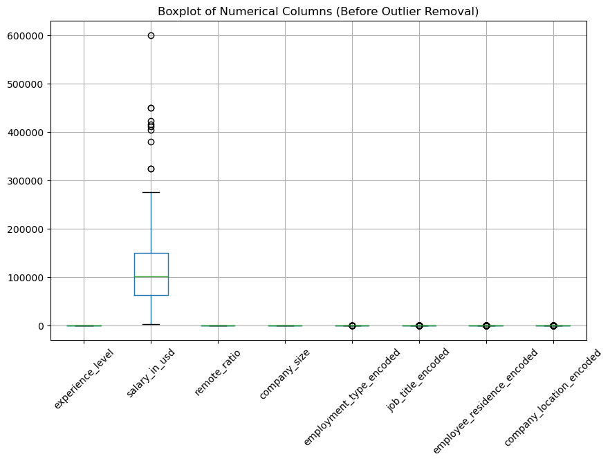

```python
# Display boxplots before removing outliers
display_boxplots(data_without_working_year, 'Boxplot of Numerical Columns (Before Outlier Removal)')
```

Como podemos observar, existen Outliers en la columna que deseamos predecir, es por ello que vamos a realizar un tratamiento de los mismos empleando la función descrita anteriormente. Vemos a continuación el resultado tras aplicar la función: </font>

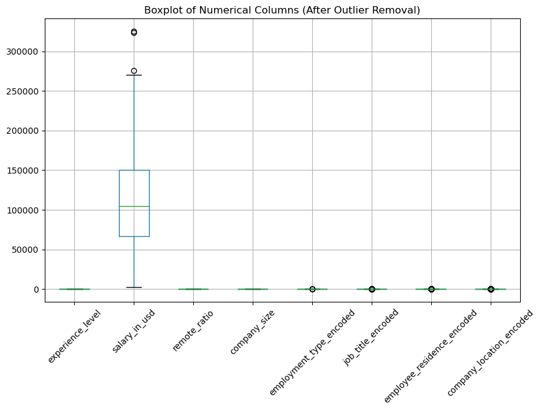

```python
# Perform outlier analysis
data_after_outliers_analysis = outlier_analysis(data_without_working_year)

# Display boxplots after removing outliers
display_boxplots(data_after_outliers_analysis, 'Boxplot of Numerical Columns (After Outlier Removal)')
```

**Modelo de regresión lineal para predecir el `salary_in_usd` en función del resto de características.**

Vamos a tratar de predecir el salario en dólares a partir del resto de variables disponibles. Para ello, vamos a usar la librería *Scikit Learn*.

En primer lugar hacemos la partición en conjunto de entrenamiento y test dejando un 80% de los datos para entrenamiento y el 20% restante para test. Usamos además una semilla para que los resultados sean reproducibles desde cualquier máquina. </font>

```python
X = data_after_outliers_analysis.drop(['salary_in_usd'], axis=1)  # Features
y = data_after_outliers_analysis['salary_in_usd']  # Target variable

# Split the data into training and testing sets
X_train, X_test, y_train, y_test = train_test_split(X, y, test_size=0.2, random_state=42)
```

En segundo lugar estandarizamos los datos. Esto implica transformar las características para que tengan una media de 0 y una desviación estándar de 1. La estandarización se utiliza a menudo cuando las características tienen diferentes unidades (como en este caso) o cuando el algoritmo es sensible a la escala de las características, como es el caso del descenso del gradiente (el que emplearemos). Así, por regla general es una buena práctica hacer esta transformación. </font>

```python
# Standardize the data
scaler = StandardScaler()
X_train_scaled = scaler.fit_transform(X_train)
X_test_scaled = scaler.transform(X_test)
```

Ahora usamos la función `SGDRegressor()` de la librería *Scikit Learn* para construir el modelo (utiliza la función MSE como función de error y el método de gradiente desdendente), realizaremos unas 1000 iteraciones del algoritmo y evaluaremos el modelo con la métrica $R^2$, que nos indica el porcentaje de la varianza explicado por el modelo sobre la variable dependiente (en este caso el `salary_in_usd`). </font>

```python
# Linear Regression using all components

# Create an instance of the SGDRegressor with the desired hyperparameters
sgd_regressor = SGDRegressor(loss="squared_error", max_iter=1000, random_state=42)

# Fit the model to your data
sgd_regressor.fit(X_train_scaled, y_train)

# Evaluate the model on the test set
test_score = sgd_regressor.score(X_test_scaled, y_test)
print(f"Linear Regression R-squared on Test Set: {test_score}")
```

```
Linear Regression R-squared on Test Set: 0.29695050986545657
```

Como vemos, el resultado del coeficiente $R^2$ es pobre, lo que nos hace pensar que quizá un ajuste lineal no es la mejor alternativa para resolver el problema, no obstante, como se ha comentado, no es el objetivo de la práctica el obtener el mejor modelo posible para este cometido. </font>

**Aplicar el algoritmo PCA para estudiar la influencia de cada característica en la varianza explicada y estudiar la viabilidad de resolcer el problema usando menos variables.**

A continuación usaremos el algoritmo *PCA* de la librería de *Scikit Learn* Para ver la influencia de cada variable independiente sobre la variable que pretendemos predecir, esto nos ayudará eliminar variables que no tengan un efecto notable en este cometido simplificando el problema y consiguiendo resultados similares con un modelo más sencillo.

Usaremos la función `PCA()` de la librería, y vemos las 6 variables con mayor influencia en la varianza de la variable dependiente: </font>

```python
# Apply PCA
pca = PCA()
X_train_pca = pca.fit_transform(X_train_scaled)
X_test_pca = pca.transform(X_test_scaled)

# Results: Explained Variance Ratio by each Principal Component
explained_variance = pca.explained_variance_ratio_
column_names = X.columns

# Selecting the top components
num_components = 6  # Selecting the top 6 components
top_components = pd.Series(explained_variance, index=column_names).nlargest(num_components)

# Get the indices of the most important components
most_important_indices = np.argsort(pca.explained_variance_)[::-1][:num_components]

print("Top Components based on Explained Variance:")
print(top_components)
print ("Cumulative variance explained: ")
print(top_components.sum())
print("Indices of most important components: ")
print(most_important_indices)
```

```
Top Components based on Explained Variance:
experience_level              0.265508
remote_ratio                  0.169384
company_size                  0.155172
employment_type_encoded       0.140609
job_title_encoded             0.125013
employee_residence_encoded    0.117754
dtype: float64
Cumulative variance explained:
0.9734404997956684
Indices of most important components:
[0 1 2 3 4 5]
```

Vamos pues a eliminar de nuestro conjunto de entrenamiento la última variable y a reentrenar el modelo de nuevo: </font>

```python
# Now PCA using only the selected components for training and testing data
X_train_pca = X_train_pca[:, most_important_indices]
X_test_pca = X_test_pca[:, most_important_indices]

# Linear Regression using TOP 5 selected PCA components
# Create an instance of the SGDRegressor with the desired hyperparameters
sgd_regressor_pca = SGDRegressor(loss="squared_error", max_iter=1000, random_state=42)

# Fit the model to your data
sgd_regressor_pca.fit(X_train_pca, y_train)

# Evaluate the model on the test set
test_score_pca = sgd_regressor_pca.score(X_test_pca, y_test)
print(f"Linear Regression R-squared on Test Set with selected components: {test_score_pca}")
```

```
Linear Regression R-squared on Test Set with selected components: 0.30313087849493237
```

Como vemos el valor de $R^2$ es casi idéntico al caso con todas las variables (incluso ligeramente superior). Con esto hemos conseguido reducir la complejidad del problema y conseguir un modelo con un rendimiento similar al caso con todas las variables. </font>

A continuación se presentan una serie de tests unitarios para poder comprobar los resultados, para ello empleamos la librería *pytest* en su versión interactiva llamada *ipytest*: </font>

```python
! pip install ipytest
```

```python
ipytest.autoconfig()
```

```python
# Pruebas de funcionamiento, también tarea del estudiante:

def test_dataframe_has_categorical_columns():
    # Get a list of column names with categorical data type
    categorical_columns = data_with_categorical.select_dtypes(include=['category']).columns
    # Check if there are categorical columns
    assert len(categorical_columns) > 0

def test_dataframe_has_not_categorical_columns():
    # Get a list of column names with categorical data type
    categorical_columns = data_no_categorical.select_dtypes(include=['category']).columns
    # Check there are no categorical columns
    assert len(categorical_columns) == 0

def test_no_working_year_column():
    # Check if 'working_year' column is not present in the DataFrame
    assert 'working_year' not in data_without_working_year.columns

def test_outliers_analysis_function():
    # Store the DataFrame before applying outlier analysis
    df_before_outliers = data_without_working_year
    # Apply the outlier analysis function
    df_after_outliers = outlier_analysis(df_before_outliers)
    # Check the number of rows before and after the analysis
    assert len(df_before_outliers) > len(df_after_outliers)
    assert len(df_after_outliers) == 547
    assert len(df_before_outliers) == 607

def test_datasets_lengths():
    # Check the length of the training and test datasets
    assert len(X_train) == 437
    assert len(X_test) == 110

def test_standarization():
    tolerance = 1e-9
    # Check if the mean and standard deviation of the scaled training data are close to 0 and 1, respectively
    assert np.allclose(X_train_scaled.mean(), 0.0, rtol=tolerance, atol=tolerance)
    assert np.allclose(X_train_scaled.std(), 1.0, rtol=tolerance, atol=tolerance)

def test_most_important_indices():
    # Define a gold list of important indices
    gold_list = [0, 1, 2, 3, 4, 5]
    # Check if the calculated list of most important indices matches the gold list
    assert gold_list == most_important_indices.tolist()

def test_scores_before_and_after_pca():
    tolerance = 1e-9
    # Check if test scores before and after PCA are within a specific tolerance
    assert np.allclose(round(test_score, 3), 0.297, rtol=tolerance, atol=tolerance)
    assert np.allclose(round(test_score_pca, 3), 0.303, rtol=tolerance, atol=tolerance)
    # Check if test score after PCA is higher than the test score before PCA
    assert test_score_pca > test_score

ipytest.run("-v")
```

```
======================================= test session starts =======================================
platform win32 -- Python 3.11.5, pytest-7.4.0, pluggy-1.0.0
rootdir: c:\Users\pablo\OneDrive\Documentos\GitHub\MasterBigDataML-PythonCourse\python project\-- data_science_salaries
plugins: anyio-3.5.0
collected 8 items

t_057f68afe1954a13bd082e085ab2c0d0.py ........                                               [100%]

======================================== 8 passed in 0.03s ========================================
```

```
<ExitCode.OK: 0>
```

### Datos personales

- **Apellidos:** Borrego Megías
- **Nombre:** Alejandro
- **Email:** alejbormeg@gmail.com
- **Fecha:** 19/10/2023

### Ficha de autoevaluación

[output not shown]

### Ayuda recibida y fuentes utilizadas

Las fuentes principales empleadas para la elaboración del trabajo han sido las siguientes (son enlaces a los sitios web de la documentación oficial):

- [PEP 8 Style Guide](https://peps.python.org/pep-0008/)
- [Librería csv](https://docs.python.org/3/library/csv.html)
- [Numpy](https://numpy.org/)
- [Pandas](https://pandas.pydata.org/)
- [PCA](https://scikit-learn.org/stable/modules/generated/sklearn.decomposition.PCA.html)
- [Scikit-Learn Linear Regression](https://scikit-learn.org/stable/modules/generated/sklearn.linear_model.SGDRegressor.html)
- [Libreria ipytest](https://jupyter-tutorial.readthedocs.io/en/stable/notebook/testing/ipytest.html)
- [Matplotlib](https://matplotlib.org/)
- [Python Collections Dictionaries](https://docs.python.org/3/library/collections.html)
- Apuntes del módulo y material audiovisual para el ejercicio de Map-Reduce

### Comentario adicional

La práctica ha sido complicada de realizar por la gran cantidad de iteraciones que han sido necesarias para aclarar algunos enunciados confusos y eliminar erratas. No obstante, a su vez esta iteración con el profesor me ha hecho experimentar una mayor similitud con el desarrollo de proyectos software en el mundo laboral.

```python
# Esta celda se ha de respetar: está aquí para comprobar el funcionamiento de algunas funciones por parte de tu profesor
```